# Distributions of Random Variables

## Standardizing with Z Scores

SAT scores are distributed nearly normally with mean 1500 and standard deviation 300. ACT scores are distributed nearly normally with mean 21 and standard deviation 5. A college admissions officer wants to determine which of the two applicants scored better on their standardized test with respect to the other test takers: Pam, who earned an 1800 on her SAT, or Jim, who scored a 24 on his ACT?

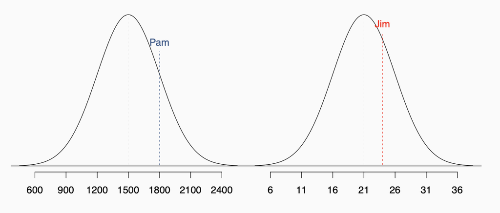

- Can we compare their raw scores?
- What should we do instead?
- We can compare how many standard deviations beyond the mean that each observation is
  - Pam’s score: $\frac{1800-1500}{300} \ = \ 1$
    - Pam’s score is 1 standard deviation above the mean
  - Jim’s score: $\frac{24-21}{5} \ = \ 0.6$
    - Jim’s score is 0.6 standard deviations above the mean

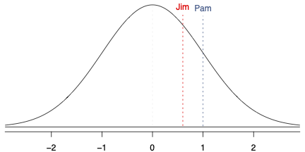

- These standardized scores are called Z scores
- The Z score of an observation is the number of standard deviations it falls above or below the mean

$Z \ = \ \frac{observation-mean}{SD}$

- Z scores are defined for distributions of any shape, but only when the distribution is normal can we use Z scores to calculate percentiles
- Observations that are more than two standard deviations away from the mean $(|Z| > 2)$ are usually considered unusual

## Percentiles

- A percentile is the percentage of observations that fall below a given data point
- Graphically, percentile is the area below the probability distribution curve to the left of that observation

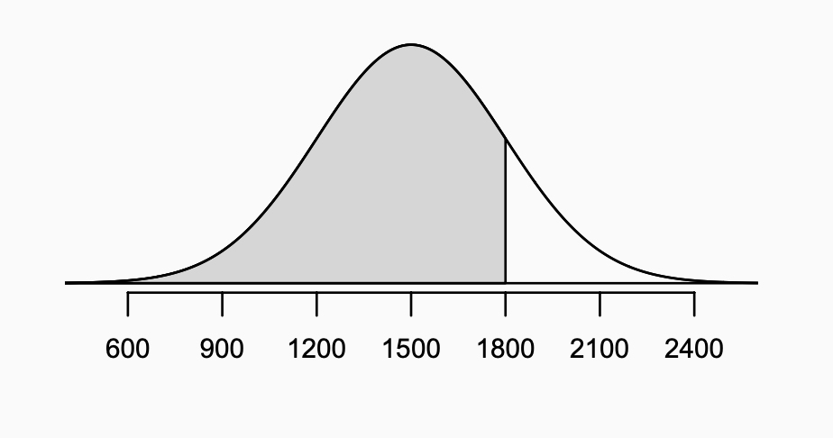

### Calculating Percentiles

- There are many ways to compute percentiles/area under the curve
- In R:

```r
pnorm(1800, mean = 1500, sd = 300)
```

```
## [1] 0.8413447
```

### Using Z Score Tables

- We have to calculate our Z score

$Z \ = \ \frac{1800-1500}{300} \ = \ 1$

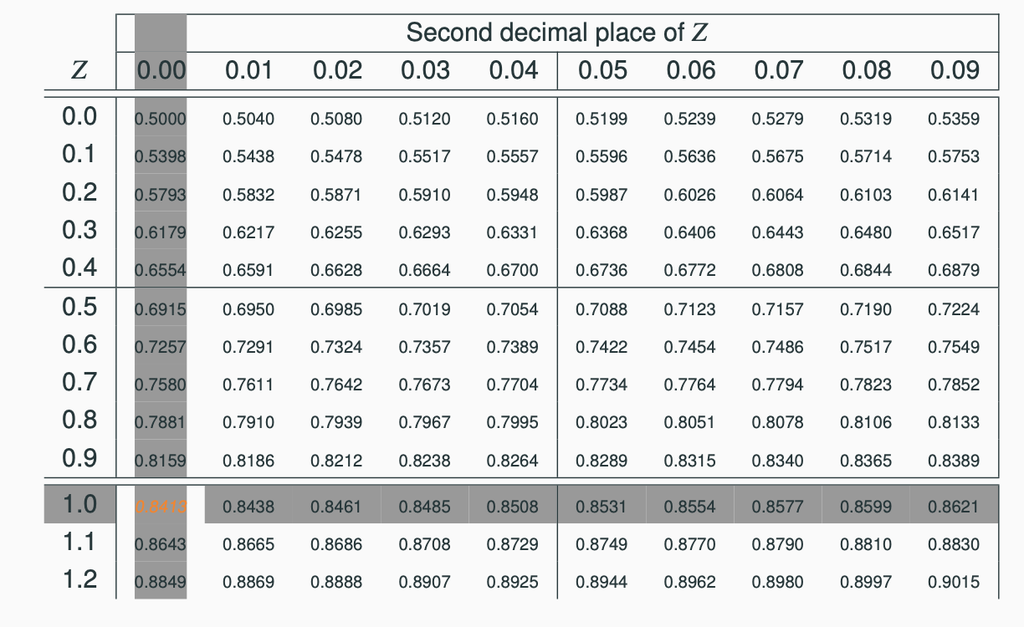

- The data to the left, under the curve, equals 0.8413

## Example

At Heinz ketchup factory the amounts which go into bottles of ketchup are supposed to be normally distributed with mean 36 oz. and standard deviation 0.11 oz. Once every 30 minutes a bottle is selected from the production line, and its contents are noted precisely. If the amount of ketchup in the bottle is below 35.8 oz. or above 36.2 oz., then the bottle fails the quality control inspection. What percent of bottles have less than 35.8 ounces of ketchup?

Let X = amount of ketchup in a bottle: $X ~ N(\mu = 36, \sigma = 0.11)$

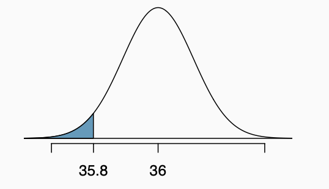

- We need to calculate our Z score

$Z = \frac{35.8-36}{0.11} \ = \ -1.82$

**Using R**

```r
pnorm(-1.82, mean = 0, sd = 1)
```

```
## [1] 0.0343795
```

```r
#OR

pnorm(35.8, mean = 36, sd = 0.11)
```

```
## [1] 0.03451817
```

- What percent of bottles pass the quality control inspection?
  - (A). 1.82%
  - (B). 3.44%
  - (C). 6.88%
  - (D). 93.12%
  - (E). 96.56%
- (D). 93.12%
  - Why?

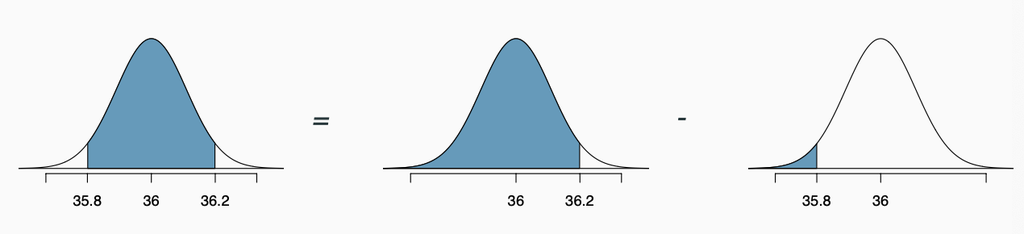

$Z = \frac{35.8-36}{0.11} \ = \ -1.82$

$Z = \frac{36.2-36}{0.11} \ = \ 1.82$

$P(35.8 \ < \ X \ < \ 36.2) \ = \ P(-1.82 \ < \ Z \ < \ 1.82)$

$= \ 0.9656 - 0.0344$

$= \ 0.9312$

## 68-95-99.7 Rule

- For nearly normally distributed data:
  - about 68% of all data fall within 1 SD of the mean
  - about 95% of all data fall within 2 SD of the mean
  - about 99.7% of all data fall within 3 SD of the mean
- It is possible for observations to fall 4, 5, or more standard deviations away from the mean, but these occurrences are very rare if the data are nearly normal

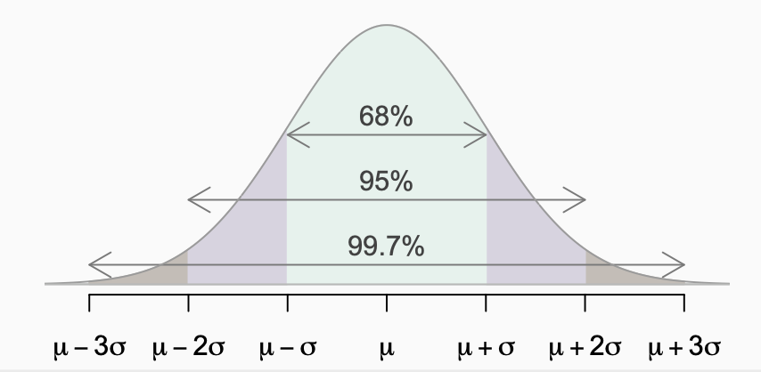

**Describing Variability Using the 68-95-99.7 Rule**

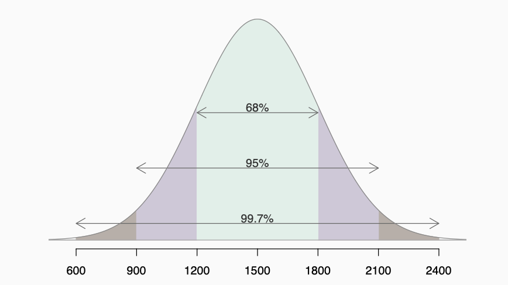